# Economia naranja

Xavier Enriquez

2023-04-12

```r
orangeec <- read.csv("C:/Users/xenriquez/Documents/XE SERVIMAX/R/orangeec.csv")
data(orangeec)
summary(orangeec)
```

```
##    Country              GDP.PC       GDP.US.bill         GDP.Growth..
##  Length:17          Min.   : 5600   Min.   :     13.7   Min.   :0.800
##  Class :character   1st Qu.: 8300   1st Qu.:     37.1   1st Qu.:2.000
##  Mode  :character   Median :13300   Median :     75.7   Median :2.800
##                     Mean   :14053   Mean   : 188693.0   Mean   :2.959
##                     3rd Qu.:19900   3rd Qu.:    309.2   3rd Qu.:4.200
##                     Max.   :25400   Max.   :2055000.0   Max.   :5.400
##
##  Services...GDP  Creat.Ind...GDP   Inflation       Unemployment
##  Min.   :50.00   Min.   :1.000   Min.   : 0.400   Min.   : 2.300
##  1st Qu.:56.90   1st Qu.:2.000   1st Qu.: 1.600   1st Qu.: 5.500
##  Median :62.20   Median :2.600   Median : 3.400   Median : 6.700
##  Mean   :62.64   Mean   :3.291   Mean   : 4.365   Mean   : 6.794
##  3rd Qu.:64.90   3rd Qu.:3.950   3rd Qu.: 4.300   3rd Qu.: 8.100
##  Max.   :82.00   Max.   :7.400   Max.   :25.700   Max.   :11.800
##                  NA's   :6
##  X..pop.below.poverty.line Internet.penetration...population   Median.age
##  Min.   : 4.20             Min.   :38.20                     Min.   :22.10
##  1st Qu.:21.70             1st Qu.:57.70                     1st Qu.:25.70
##  Median :25.70             Median :69.70                     Median :28.20
##  Mean   :27.65             Mean   :68.42                     Mean   :28.28
##  3rd Qu.:32.70             3rd Qu.:79.90                     3rd Qu.:31.30
##  Max.   :59.30             Max.   :93.10                     Max.   :35.00
##
##   X..pop.25.54   Education.invest...GDP
##  Min.   :34.12   Min.   :2.800
##  1st Qu.:39.23   1st Qu.:4.400
##  Median :40.19   Median :5.000
##  Mean   :39.88   Mean   :5.082
##  3rd Qu.:41.08   3rd Qu.:5.900
##  Max.   :44.03   Max.   :7.400
##
```

Parece que hay correlación entre aporte de economía naranja al PIB y la tasa de desempleo

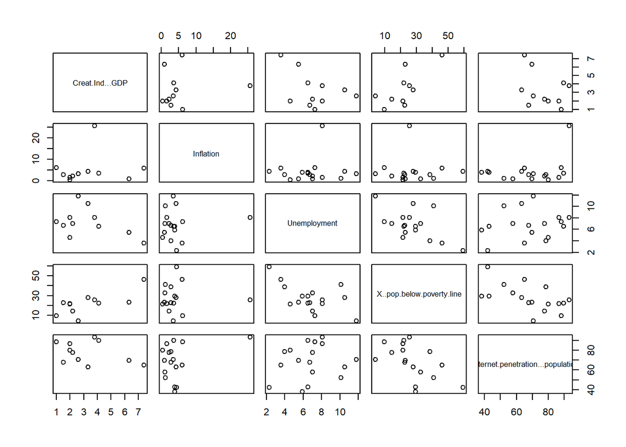

```r
pairs(orangeec[,6:10])
```

```r
library(ggplot2)
```

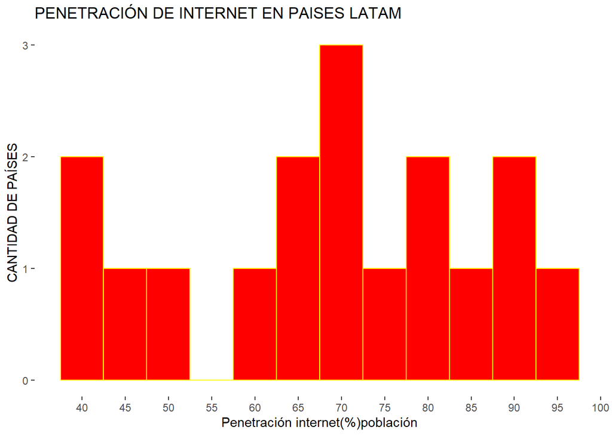

```r
ggplot() + geom_histogram(data=orangeec,
                          aes(x=Internet.penetration...population), fill="red", color="yellow",
                          binwidth = 5)+
  labs(x="Penetración internet(%)población", y="CANTIDAD DE PAÍSES",
       title="PENETRACIÓN DE INTERNET EN PAISES LATAM") +
  scale_x_continuous(breaks = seq(40, max(100),5))+ # con esta línea coloco todos los datos en el eje X
  theme(legend.position = "none")+
  theme(panel.background =  element_blank(),panel.grid.major = element_blank(),
        panel.grid.minor = element_blank())
```

El promedio del PIB per cápita en la región es el siguiente

```r
library(dplyr)
economy <- mean(orangeec$GDP.PC)
economy
```

```
## [1] 14052.94
```

```r
orangeec <- orangeec %>%
  mutate(Strong_economy = ifelse(GDP.PC < economy,
                    "Por debajo del promedio PIB per cápita",
                    "Sobre el promedio PIB per cápita"))
```

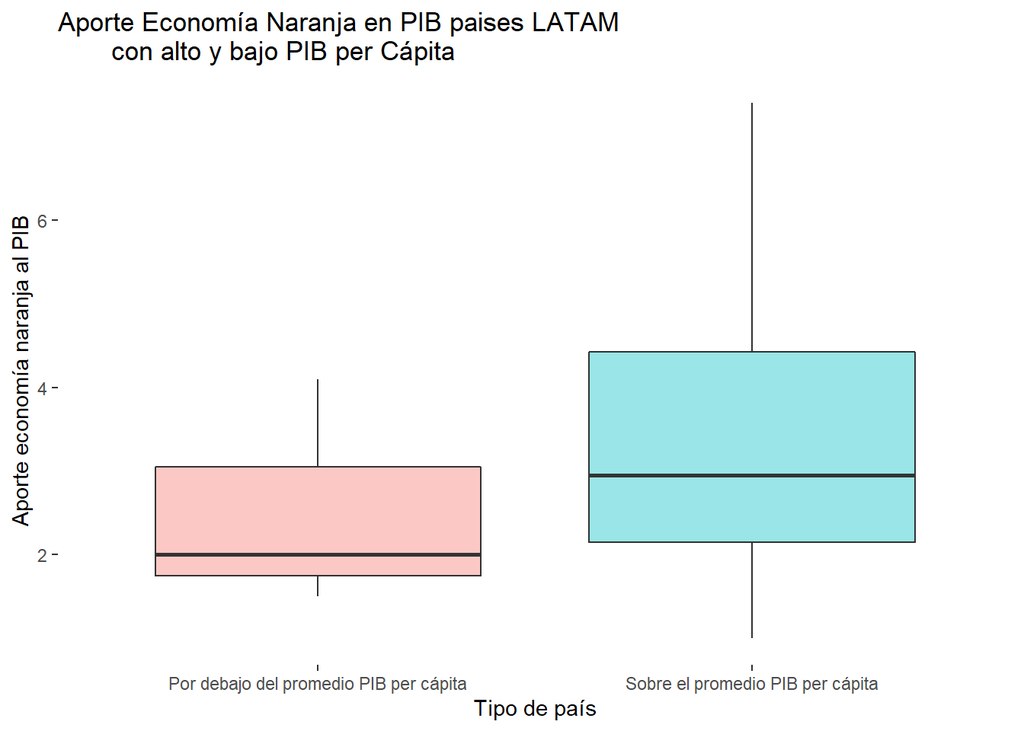

```r
ggplot(orangeec, aes(x=Strong_economy, y=Creat.Ind...GDP,
                     fill=Strong_economy))+
  geom_boxplot(alpha=0.4)+
  labs(x="Tipo de país", y="Aporte economía naranja al PIB",
       title = "Aporte Economía Naranja en PIB paises LATAM
       con alto y bajo PIB per Cápita")+
  theme(legend.position = "none")+ #esta parte quita el fondo gris
  theme(panel.background =  element_blank(),panel.grid.major = element_blank(),
        panel.grid.minor = element_blank())
```

```r
library(dplyr)
orangeec <- orangeec %>%
  mutate(Crecimiento_GDP = ifelse(GDP.Growth.. >= 2.5,
                                  "2.5% o más","Menos 2.5%"))

orangeec <- orangeec %>%
  mutate(Anaranjados = ifelse(Creat.Ind...GDP >= 2.5, ## el mutate sirve para agregar columnas
                              "Más anaranjados", "Menos anaranjados"))

#ranking

orangeec %>%
  arrange(desc(Creat.Ind...GDP))
```

```
##        Country GDP.PC GDP.US.bill GDP.Growth.. Services...GDP Creat.Ind...GDP
## 1       Mexico  19900   1149000.0          2.0           64.0             7.4
## 2       Panama  25400        61.8          5.4           82.0             6.3
## 3     Paraguay   9800        29.6          4.3           54.5             4.1
## 4    Argentina  20900       637.7          2.9           60.9             3.8
## 5     Colombia  14500       309.2          1.8           61.4             3.3
## 6       Brazil  15600   2055000.0          1.0           72.8             2.6
## 7        Chile  24500       277.0          1.5           64.3             2.2
## 8   Costa Rica  16900        58.1          3.2           73.5             2.0
## 9      Ecuador  11500       102.3          2.7           56.9             2.0
## 10        Peru  13300       215.2          2.5           56.8             1.5
## 11     Uruguay  22400        58.4          3.1           68.8             1.0
## 12      Belize   8300      1854.0          0.8           62.2              NA
## 13     Bolivia   7500        37.1          4.2           50.0              NA
## 14 El Salvador   8900        28.0          2.4           64.9              NA
```

[output cut: 75 more lines]

```r
TopNaranjas <- orangeec %>%
  filter(Country %in% c("Mexico", "Panama","Argentina","Colombia","Brazil","Paraguay") )

TopNaranjas
```

```
##     Country GDP.PC GDP.US.bill GDP.Growth.. Services...GDP Creat.Ind...GDP
## 1 Argentina  20900       637.7          2.9           60.9             3.8
## 2    Brazil  15600   2055000.0          1.0           72.8             2.6
## 3  Colombia  14500       309.2          1.8           61.4             3.3
## 4    Mexico  19900   1149000.0          2.0           64.0             7.4
## 5    Panama  25400        61.8          5.4           82.0             6.3
## 6  Paraguay   9800        29.6          4.3           54.5             4.1
##   Inflation Unemployment X..pop.below.poverty.line
## 1      25.7          8.1                      25.7
## 2       3.4         11.8                       4.2
## 3       4.3         10.5                      28.0
## 4       6.0          3.6                      46.2
## 5       0.9          5.5                      23.0
## 6       3.6          6.5                      22.2
##   Internet.penetration...population Median.age X..pop.25.54
```

[output cut: 20 more lines]

```r
#TOP
TopNaranjas %>%
  arrange(desc(Creat.Ind...GDP))
```

```
##     Country GDP.PC GDP.US.bill GDP.Growth.. Services...GDP Creat.Ind...GDP
## 1    Mexico  19900   1149000.0          2.0           64.0             7.4
## 2    Panama  25400        61.8          5.4           82.0             6.3
## 3  Paraguay   9800        29.6          4.3           54.5             4.1
## 4 Argentina  20900       637.7          2.9           60.9             3.8
## 5  Colombia  14500       309.2          1.8           61.4             3.3
## 6    Brazil  15600   2055000.0          1.0           72.8             2.6
##   Inflation Unemployment X..pop.below.poverty.line
## 1       6.0          3.6                      46.2
## 2       0.9          5.5                      23.0
## 3       3.6          6.5                      22.2
## 4      25.7          8.1                      25.7
## 5       4.3         10.5                      28.0
## 6       3.4         11.8                       4.2
##   Internet.penetration...population Median.age X..pop.25.54
```

[output cut: 20 more lines]

Este análisis muestra que los 6 países con más aporte a la Economía Naranja son: Mexico, Panama, Paraguay, Argentina, Colombia y Brasil.

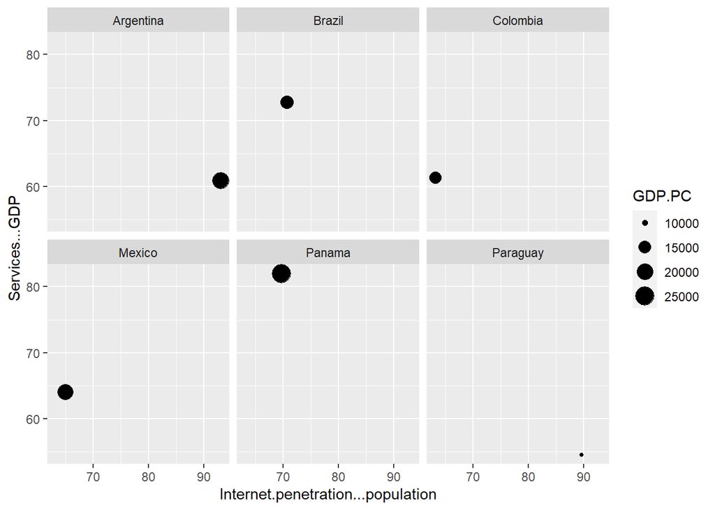

```r
library(ggplot2) # Cargar el paquete ggplot2
library(dplyr) # Cargar el paquete dplyr
library(scales) # Cargar el paquete scales

ggplot(TopNaranjas, aes(x=Internet.penetration...population,
                        y=Services...GDP,
                        size=GDP.PC)) +
  geom_point()+
  facet_wrap(~Country)
```

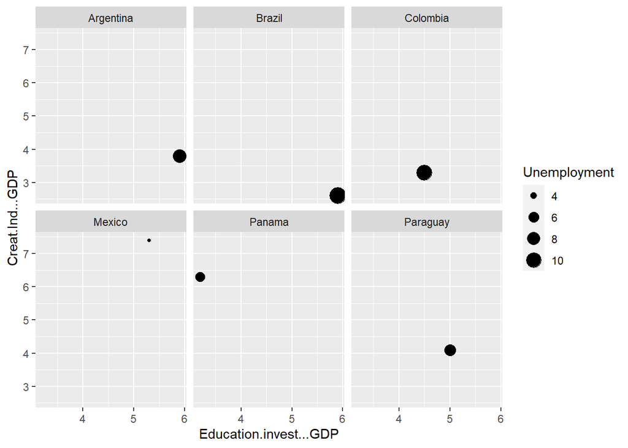

```r
#
ggplot(TopNaranjas, aes(x=Education.invest...GDP,
                        y=Creat.Ind...GDP,
                        size=Unemployment)) +
  geom_point()+
  facet_wrap(~Country)
```

Más análisis de los top 6 países de Economía Naranja.

Por otro lado, Panamá es el país que tiene la mayor particiáción de PIB per cápita y los servicios aportan en gran medida al PIB del país. Esto se entiende al aporte de la Banca y Seguros que es el fuerte del país al ser considerado como un centro financiero importante y atractivo a nivel mundial.

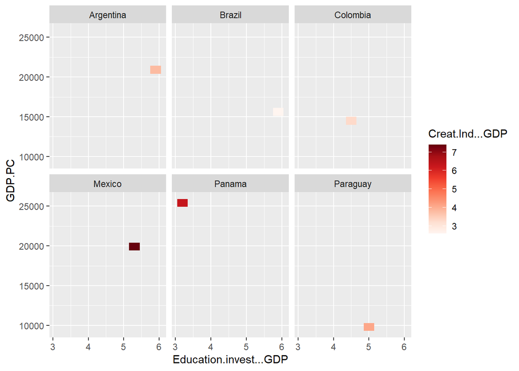

```r
library(RColorBrewer)

myColors <- brewer.pal(9,"Reds")

ggplot(TopNaranjas, aes(x = Education.invest...GDP,
                        y = GDP.PC,
                        fill = Creat.Ind...GDP)) +
  geom_tile()+
  facet_wrap(~Country)+
  scale_fill_gradientn(colors=myColors)
```

Finalmente, analizando el aporte de la industria creativa en los top países con economía naranja, se ve que México destaca en este indicador, adicionalmente invierte una gran cantidad de presupuesto en educación y su PIB per cápita sobre pasa la media de los top 6.